# Automate Exploratory Plots

Cyrus Wakibia

Instead of copying and pasting the same code and adjusting the variables, iterate over a vector of groups (variables, categories, numeric ranges) to generate the same visual for different data sets by using a custom function.

```
In one way or another you might have been in a situation where yourself or other colleagues preferred using a GUI driven tool to generate charts or perform any process of data analysis To be honest that task is crazily daunting especially when its not a one-off task. It's even worse when you are working on a project and constantly receiving feedback that you need to work on. R is very handy in writing functions that can save you the task of redoing those repetitive tasks. You can make it robust enough, if the task you regularly do are the same, you can simplify them, by writing the necessary function. The catch is when you don't have the programming experience. Even some of the people who are new to programming will find them copying and pasting code section. The major problem with this is maintenance. You will have to go to every code section that depends on copying and pasting and make the same changes. If you forget in one of the segment you might find yourself spending much time trying to figure out what might have gone wrong and where
```

*I hope you will find this helpful, particularly when performing exploratory analysis*

Most often we find ourselves using certain charts to explore data - in the data exploratory phase. These charts may have different variations depending on what you are exploring.

You might want to explore:

```
- For a continuous variables, you might explore their distributions using density plots, histogram etc.
- For categorical variables, you might want to explore the distribution of the variable using bar charts
```

If you are involved in these tasks more regularly, you might find yourself, copying and pasting particular codes in different scripts by editing the variables. Instead of this you can consider writing a function

I love this practice:

```
If you find yourself repeating similar code multiple times, then it may be a good candidate for a function.
```

One of the things you need to understand is how to work environment and data variables. Please see the section on **Data masking and Injection** from this [article](https://dplyr.tidyverse.org/articles/programming.html) for more on this. **it’s important to understand that on how variables are referenced**

We will also use functional programming using `**{purrr}**`. Here is a quick guide on purrr by [Rebecca Barter](https://www.rebeccabarter.com/blog/2019-08-19_purrr)

There are several use cases why you may want to use a functional programming approach to generate the same chart for different data subsets:

- Explore distributions or relationships of different variables
- Communicate results for different groups
- Generate charts for custom reports using various data (sub)sets

The efficiency of using a software program you already know is quickly out-weighed by being unable to easily reproduce the plots when needed. I know I invariably have to re-make even exploratory plots, and it’d be a bummer if I had to remake them all manually rather than re-running some code.

For this case we will use the **mpg** dataset which is loaded from `ggplot2`

# setup - Theme to use globally {How we want our charts to look like}

**Unfold to see code**

Set chunk options

```r
knitr::opts_chunk$set(
  fig.dpi = 300,
  collapse = TRUE,
  out.width = "100%",
  out.height = "100%",
  warning = FALSE,
  echo = TRUE
  )
```

# Use Case

Here we are going to create a chart that we use to build our case on why using functional programing is essential We use the manufacturer to color our chart scatterplot{}

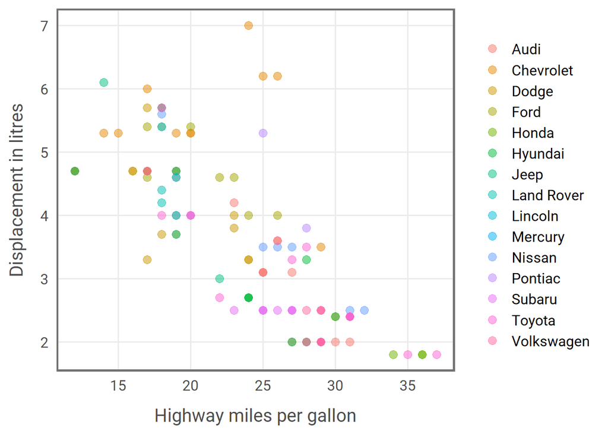

```r
g <-
  ggplot(mpg, aes(x = hwy, y = displ)) +
  scale_x_continuous(breaks = 2:8*5) +
  labs(x = "Highway miles per gallon", y = "Displacement in litres", color = NULL)

g + geom_point(aes(color = manufacturer), alpha = .5, size = 3)
```

```r
ggsave("cluttered_chart.png", bg="white", units="in", width=9, height=6,
       path = here('image'))
```

For the above chart we see that there are so many manufacturers (the color variable), this makes it’s hard to interpret and do comparisons for the different categories

One way we can enhance comparison of the different categories is through faceting - We create separate charts for each of the manufacture. The number of charts to be generated will be dependent on the number of unique categories of the faceting variable

Using ggplot2, it is easy to facet chart, using the `ggplot2::facet_wrap()` function

### Faceting

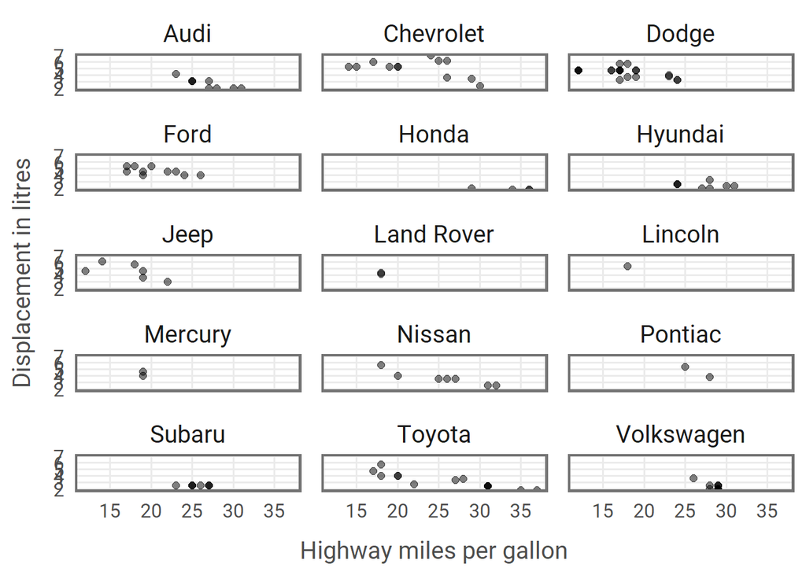

```r
 g +
  geom_point(alpha = .5, size = 2) +
  facet_wrap(~ manufacturer, ncol = 3)
```

Using the chart we created in the introduction, we can choose to “brush” the areas we don’t want, by filtering out the data b y our variable of interest

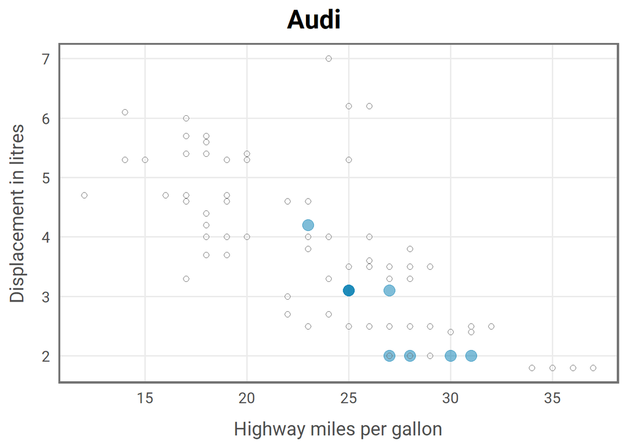

```r
g +
  ## filter for manufacturer of interest
  geom_point(data = filter(mpg, manufacturer == "Audi"),
             color = "#007cb1", alpha = .5, size = 4) +
  ## add shaded points for other data
  geom_point(data = filter(mpg, manufacturer != "Audi"),
             shape = 1, color = "grey45", size = 2) +
  ## add title manually
  ggtitle("Audi")
```

# Introducing Function

Instead of passing the group - the variable to add color or facet the chart manually, we are going to create a function

In the function we are going to pass the values of the variable we will be adding aesthetics with like color, shape, and so forth

We will check whether the value passed is passed part of the variable we are using for aesthetics - if it’s not we will stop and prompt the user that the value passed is not in the variable

**The value is also passed as a string**

**Unfold to see code**

```r
plot_manufacturer <- function(group) {

  ## check if input is valid
  if (!group %in% mpg$manufacturer) stop("Manufacturer not listed in the data set.")

  ggplot(mapping = aes(x = hwy, y = displ)) +
    ## filter for manufacturer of interest
    geom_point(data = filter(mpg, manufacturer %in% group),
               color = "#007cb1", alpha = .5, size = 4) +
    ## add shaded points for other data
    geom_point(data = filter(mpg, !manufacturer %in% group),
               shape = 1, color = "grey45", size = 2) +
    scale_x_continuous(breaks = 2:8*5) +
    ## add title automatically based on subset choice
    labs(x = "Highway gallons", y = "Displacement",
         title = group, color = NULL)
}
```

## Function Use Case

Recall, that the variable we are using for adding aesthetics is known in advance. In this case, the aesthetics variable is manufacturer. We are still building on our first chart. You can see all the values of the manufacturer by running r`unique(mpg$manufacturer)`

We will pass `Audi` and `Chevrolet` to our function as our two test cases. See below

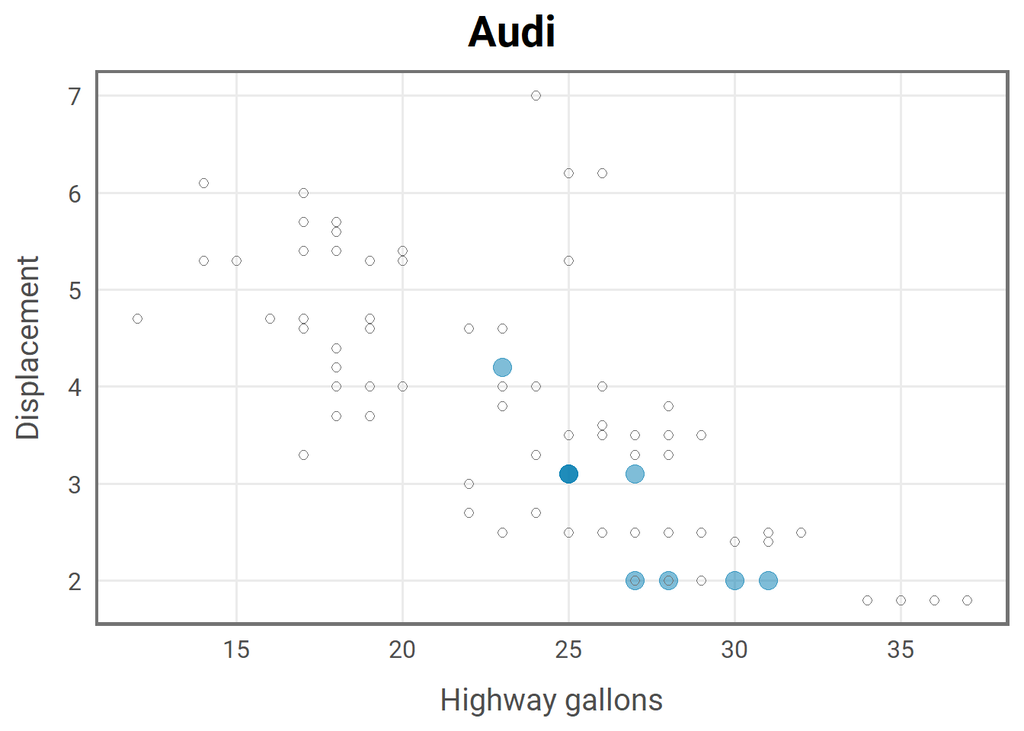

```r
## run function for specific subsets
plot_manufacturer("Audi")
```

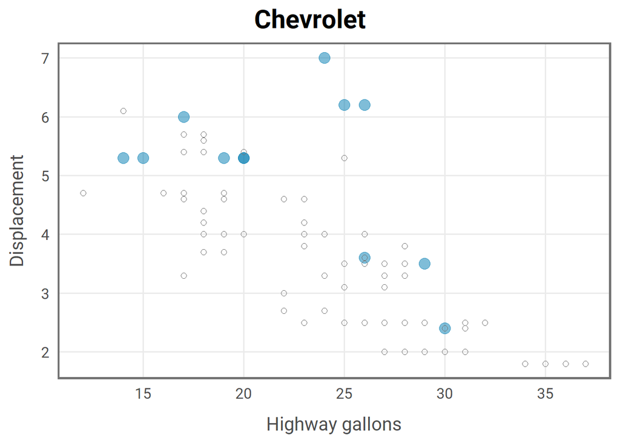

```r
plot_manufacturer("Chevrolet")
```

## The Automation

Now it can also be tedious, to pass every value to the function at a time.

We will automate this to produce the charts by passing all the groups to our functions. All the possible charts will be generated at one go

As mentioned in the introduction, we will be using `purrr` for functional programming. We are going to use most of the functions

The `map()` returns a list. This means that results returned will be a list. You can store them in a list and select them by their index position because our list is not named yet. Storing them within the list you can also use the `walk` function to save them all iteratively

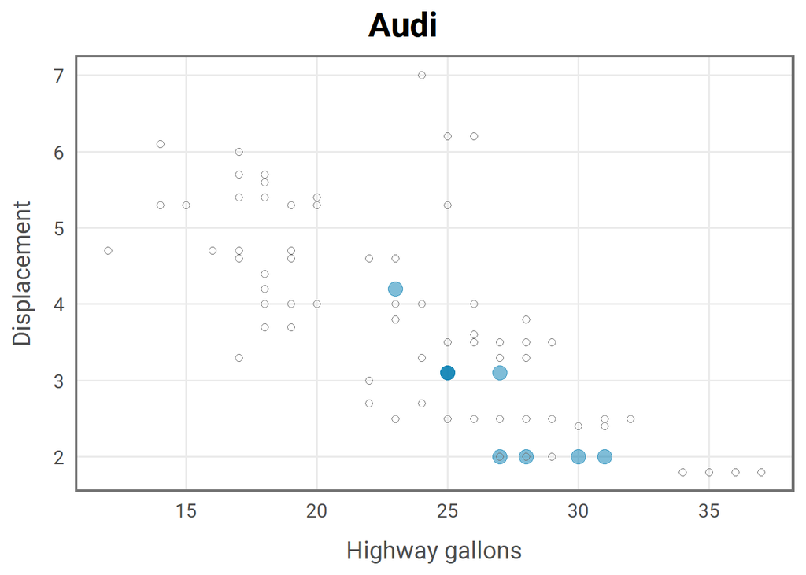

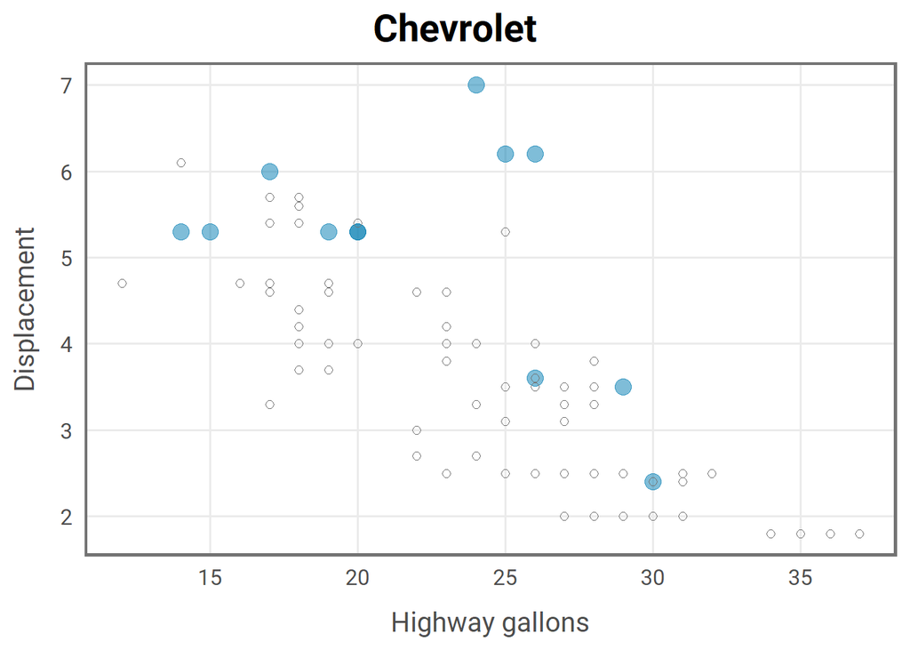

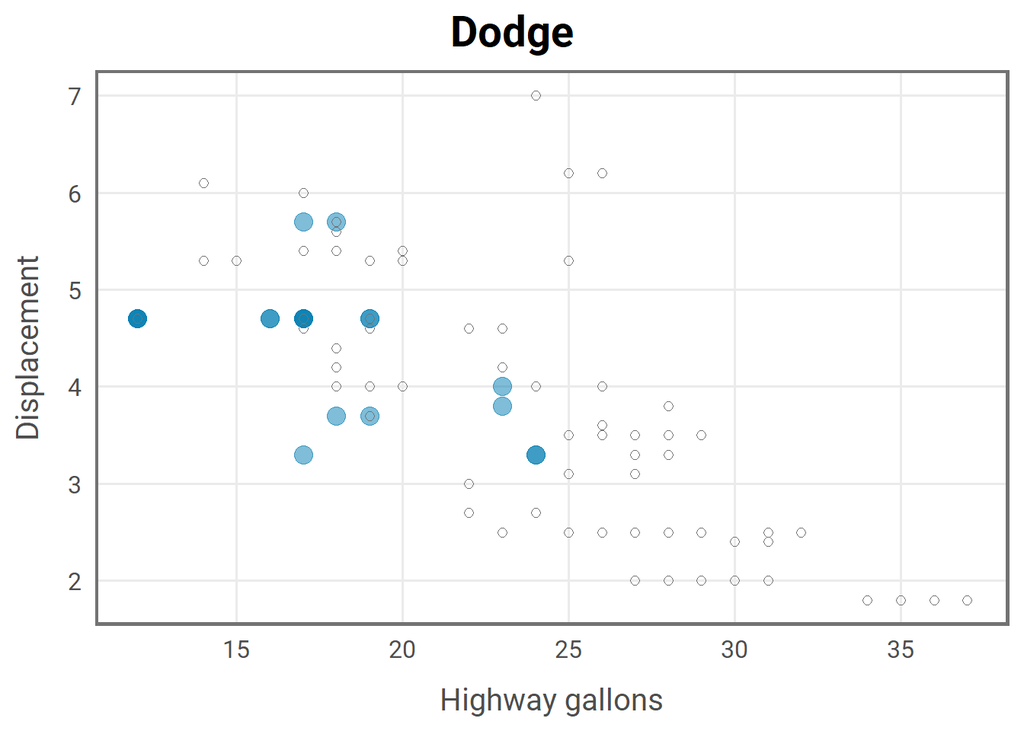

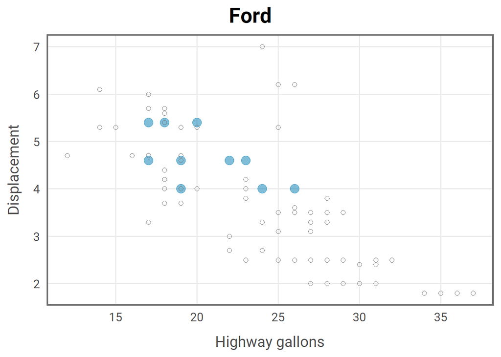

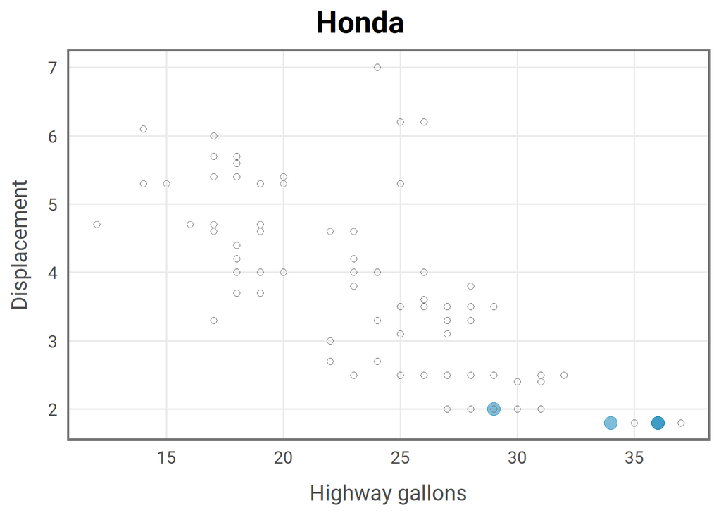

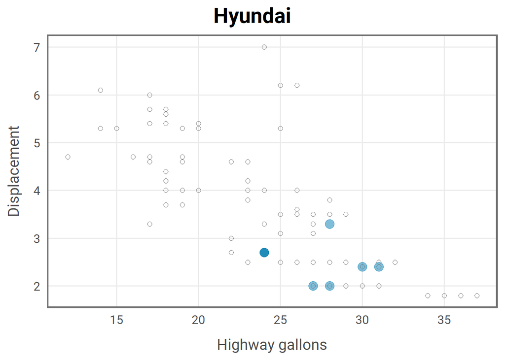

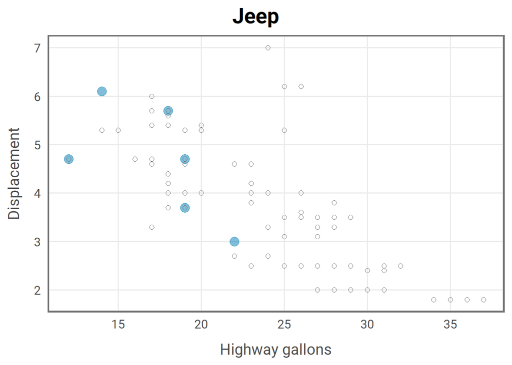

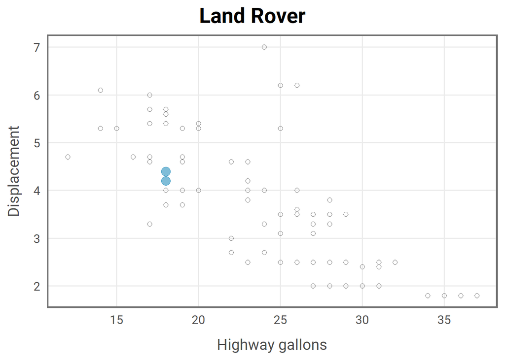

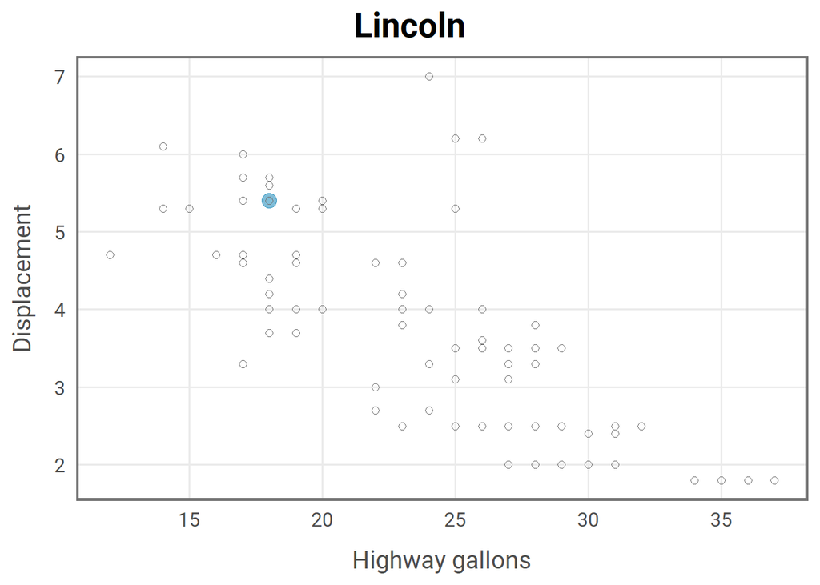

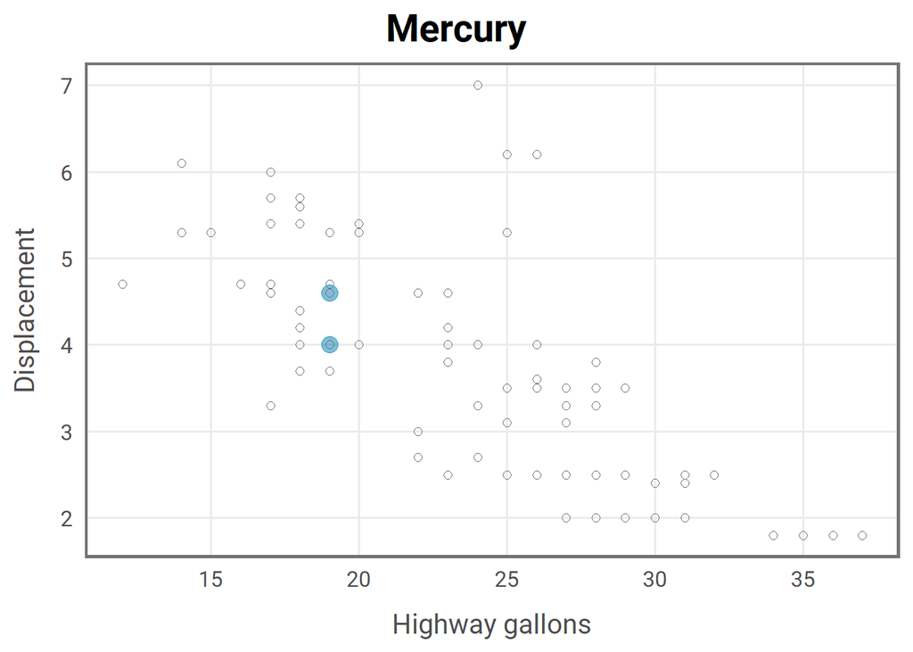

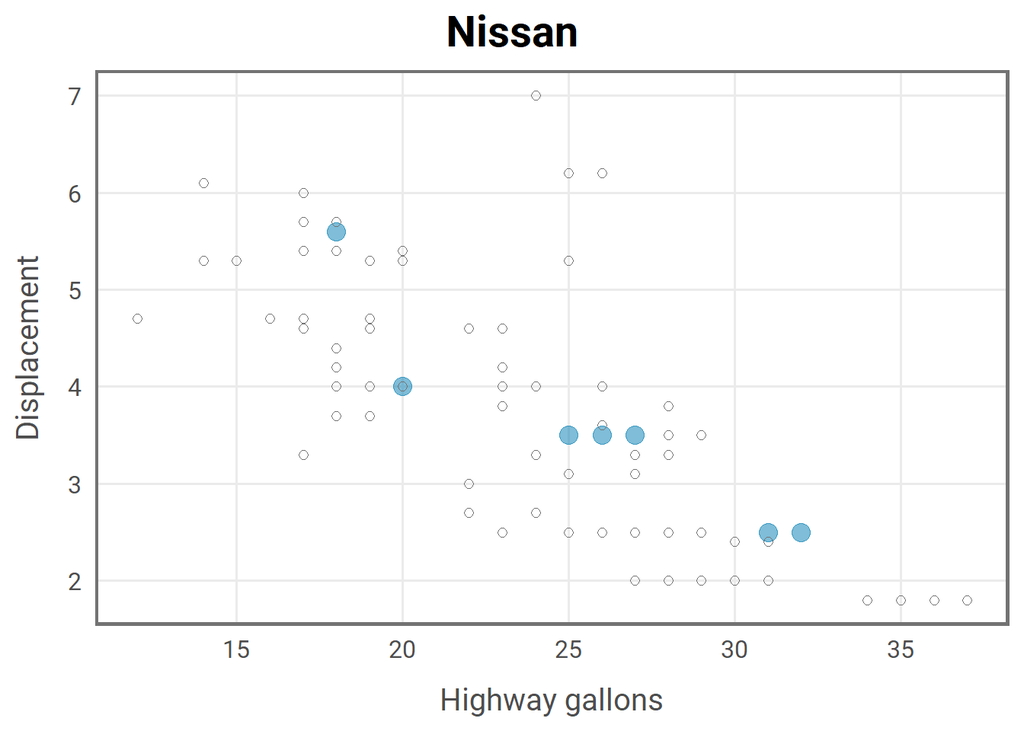

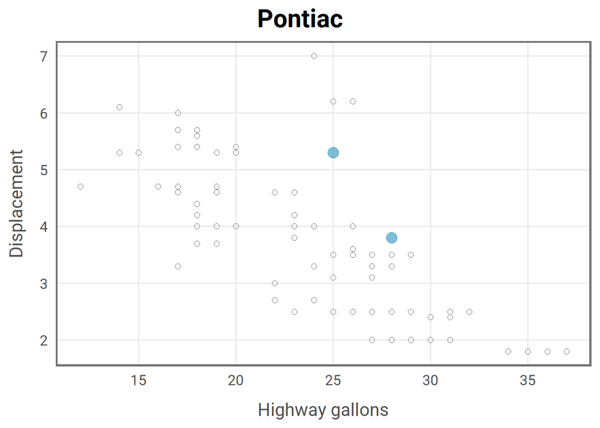

[3 more figures not shown]

```r
groups <- unique(mpg$manufacturer)
map(groups, ~plot_manufacturer(group = .x))
## [[1]]
```

```r
## store the charts in a lis
# plots <- map(groups, ~plot_manufacturer(group = .x))

## select the charts by their position
# plots[[1]] ## selects the first one\
```

## A More Complex Example

In the previous example, I pointed out that you can save the charts at one go by storing them in a list.

Here we are going to pass the `save` argument to our function which is a logical. If **`TRUE`**, the charts will be saved otherwise they will not. The value of the variable we pass is going to filter the data and create a new dataset based on the filter values

Like the previous function, our `groups` come from a predefined variable from the dataset

We will also use color palettes from `RColorBrewer`. For more on `RColorBrewer` please read [here](https://colorbrewer2.org/#type=sequential&scheme=BuGn&n=3)

**Unfold to see code**

```r
plot_manufacturer_marginal <- function(group, save = FALSE) {

  ## check if input is valid
  if (!group %in% mpg$manufacturer) stop("Manufacturer not listed in the data set.")
  if (!is.logical(save)) stop("save should be either TRUE or FALSE.")

  ## filter data
  data <- filter(mpg, manufacturer %in% group)

  ## set limits
  lims_x <- range(mpg$hwy)
  lims_y <- range(mpg$displ)

  ## define colors by the color variable (class in this case)
  pal <- RColorBrewer::brewer.pal(n = n_distinct(mpg$class), name = "Dark2")
  names(pal) <- unique(mpg$class)

  ## scatter plot
  main <- ggplot(data, aes(x = hwy, y = displ, color = class)) +
    geom_point(size = 3, alpha = .5) +
    scale_x_continuous(limits = lims_x, breaks = 2:8*5) +
    scale_y_continuous(limits = lims_y) +
    scale_color_manual(values = pal, name = NULL) +
    labs(x = "Highway miles per gallon", y = "Displacement") +
    theme(legend.position = "bottom")

  ## boxplots - each for x and y variables, appended on the top and right of the chart
  right <- ggplot(data, aes(x = manufacturer, y = displ)) +
    geom_boxplot(linewidth = .7, color = "grey45") +
    scale_y_continuous(limits = lims_y, guide = "none", name = NULL) +
    scale_x_discrete(guide = "none", name = NULL) +
    theme_void()

  top <- ggplot(data, aes(x = hwy, y = manufacturer)) +
    geom_boxplot(linewidth = .7, color = "grey45") +
    scale_x_continuous(limits = lims_x, guide = "none", name = NULL) +
    scale_y_discrete(guide = "none", name = NULL) +
    theme_void()

  ## combine plots
  p <- top + plot_spacer() + main + right +
    plot_annotation(title = group) +
    plot_layout(widths = c(1, .05), heights = c(.1, 1))

  ## save multi-panel plot
  if (isTRUE(save)) {
    ggsave(p, filename = paste0(group, ".pdf"),
           width = 6, height = 6, device = cairo_pdf,
           path = here('image'))
  }

  return(p)
}
```

### Applying the Function

`map` helps us apply the same function to different items. However, we can always run the a case to see whether our function is working as expected

### Test case 1

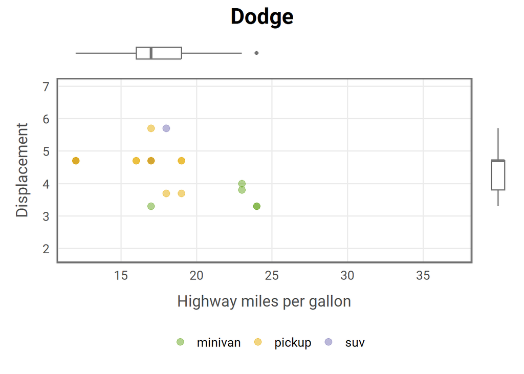

```r
plot_manufacturer_marginal("Dodge")
```

### Test case 2

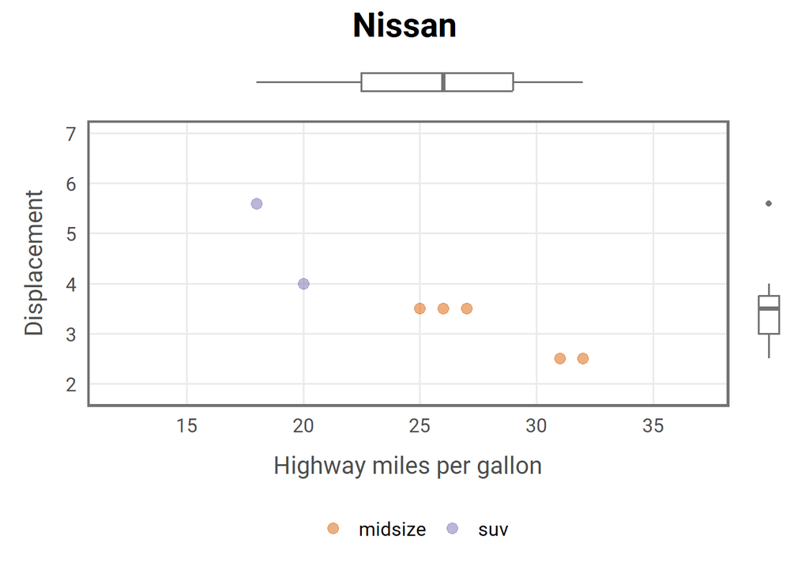

```r
# plot_manufacturer_marginal("Nissan")

### save the chart
plot_manufacturer_marginal("Nissan", save = TRUE)
```

### General Case - Using `map`

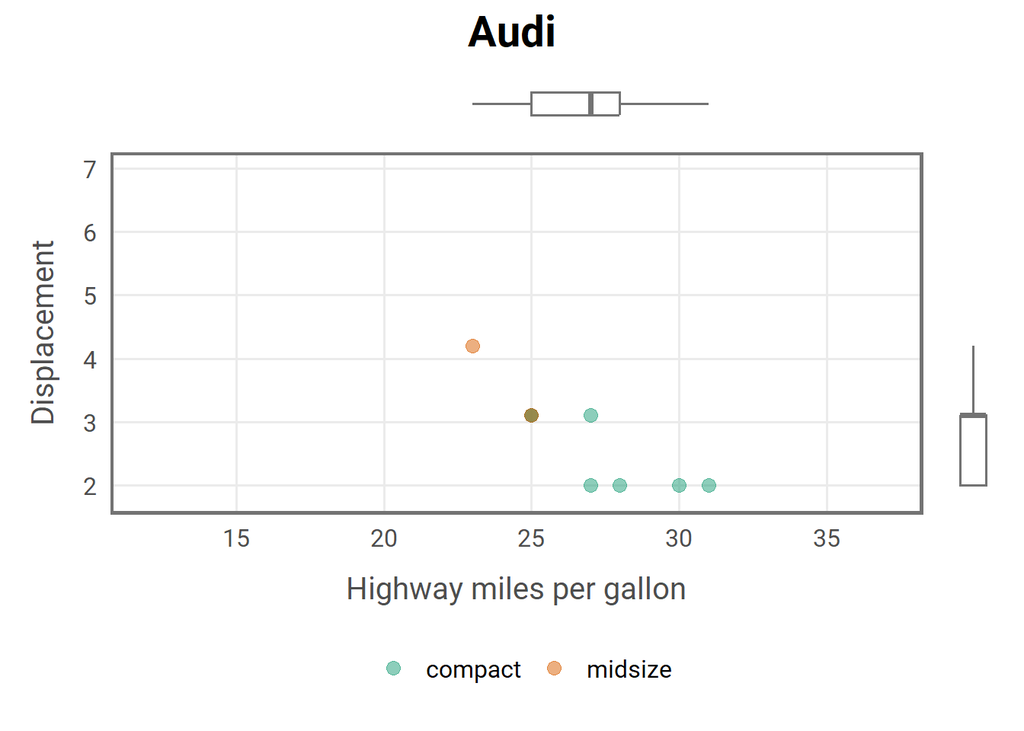

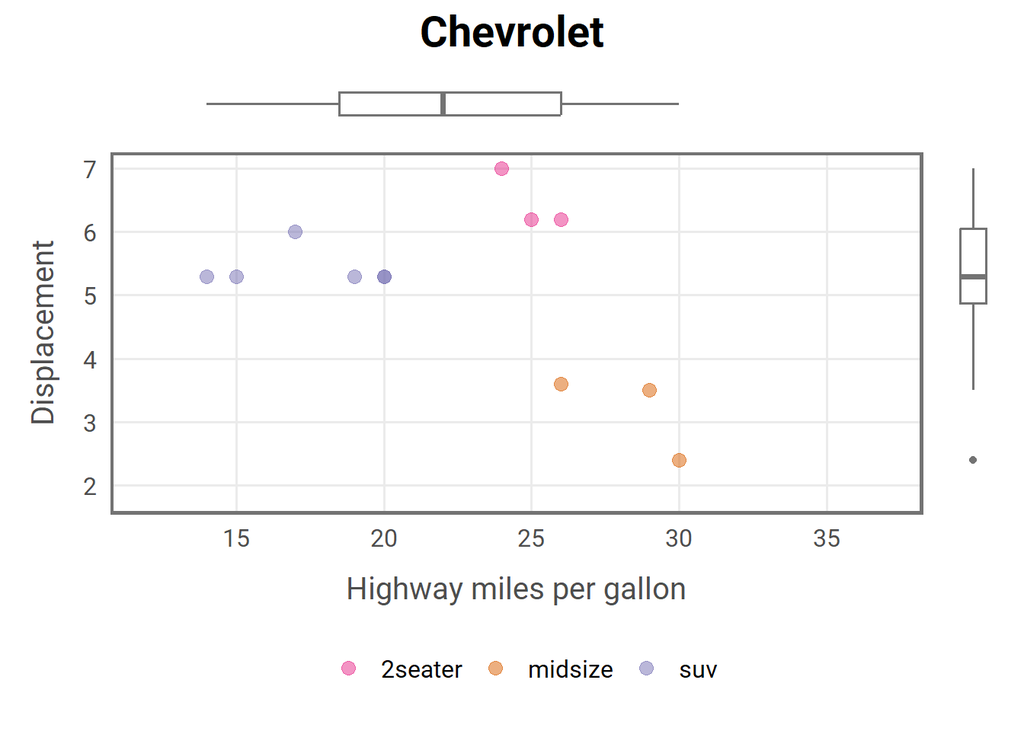

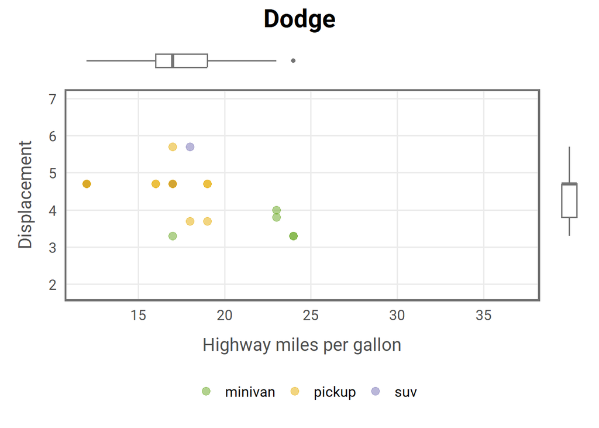

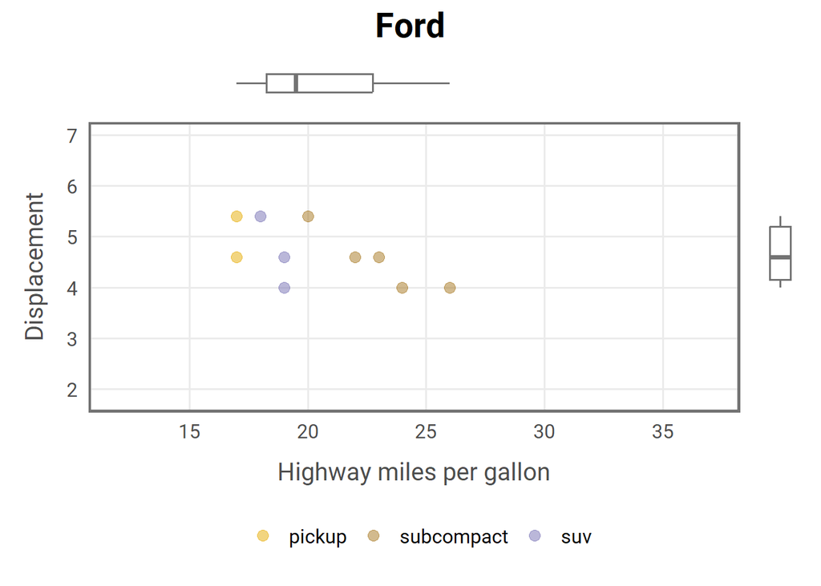

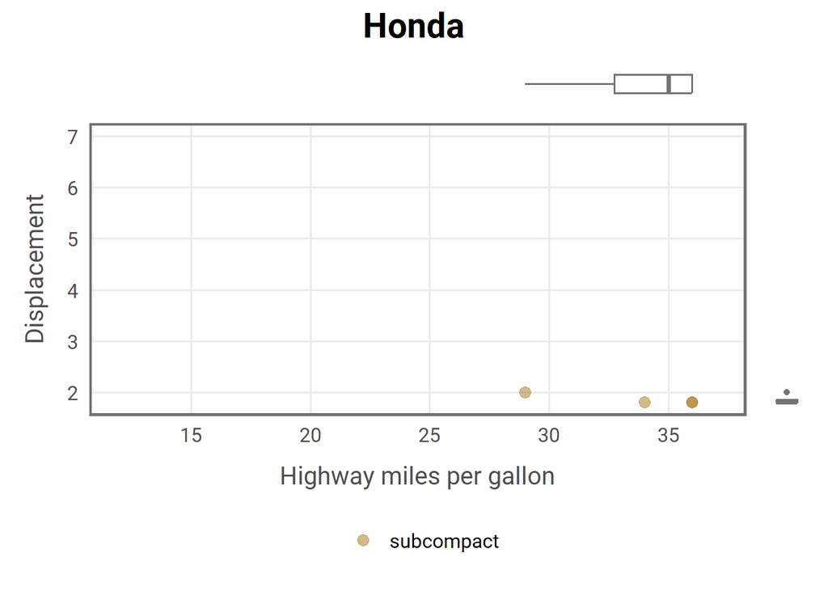

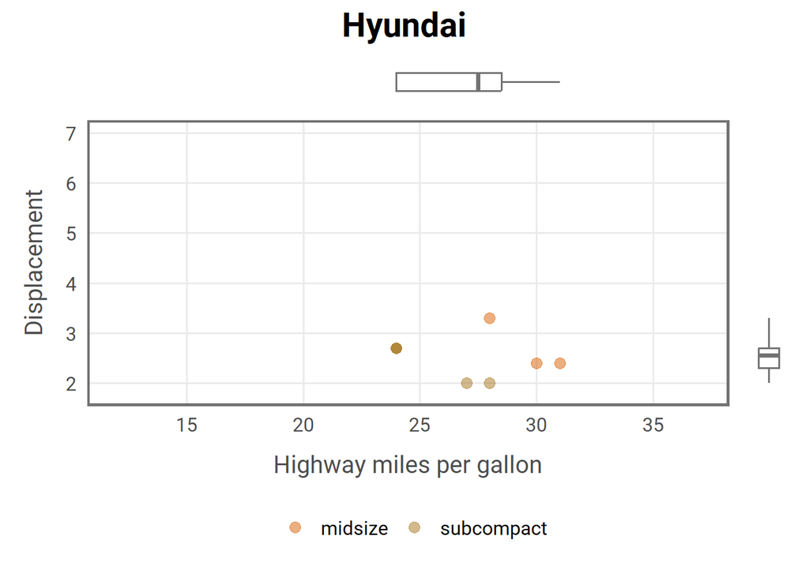

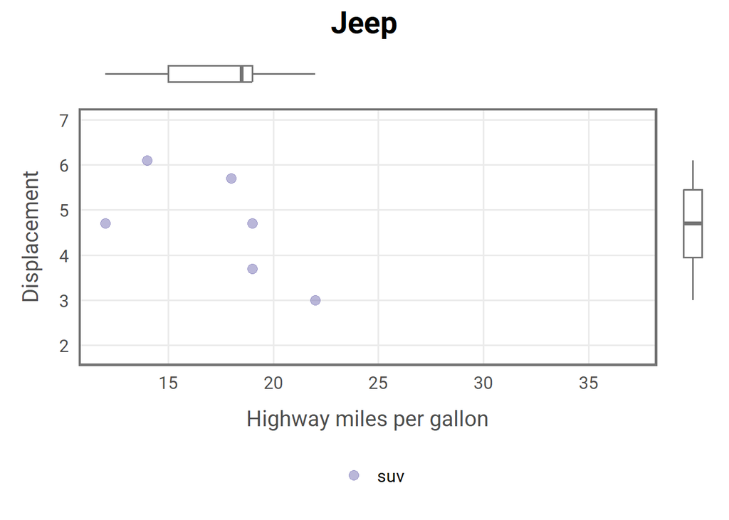

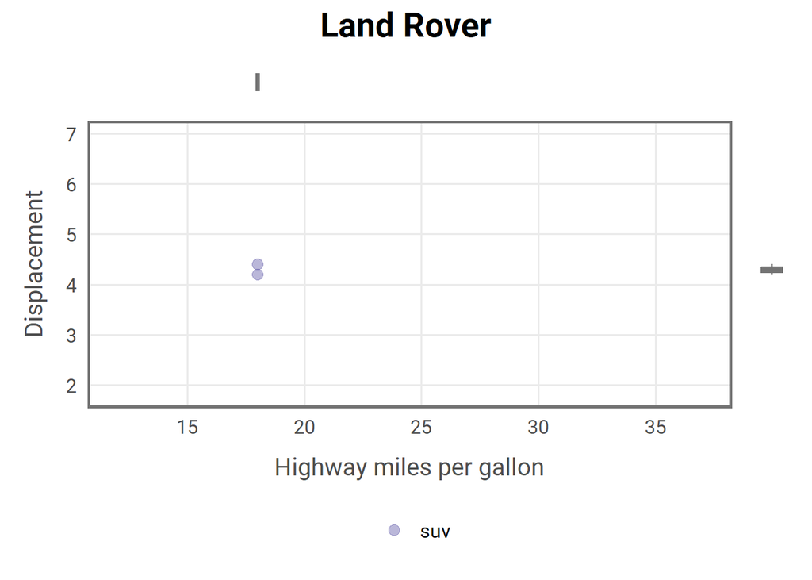

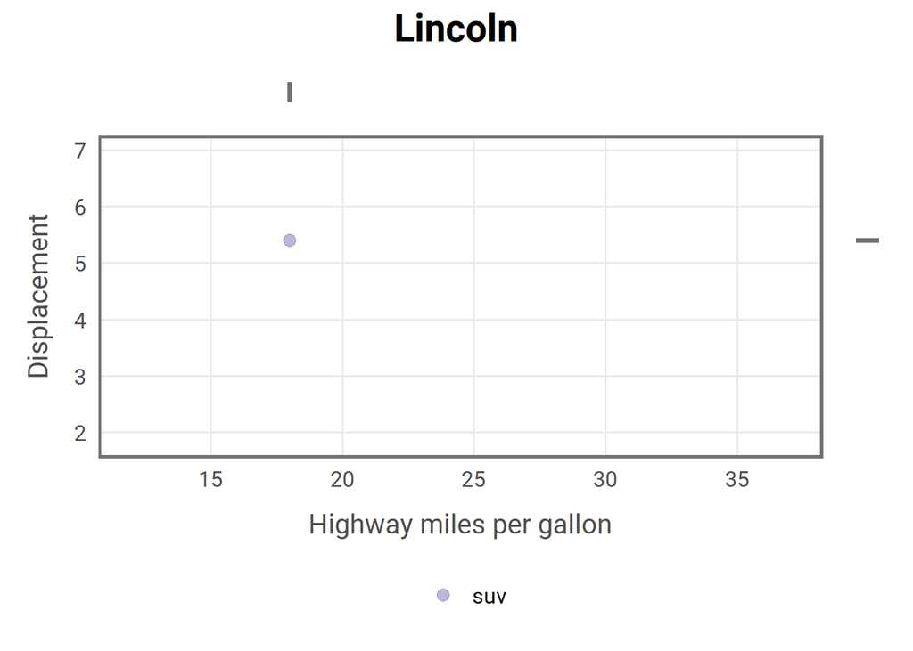

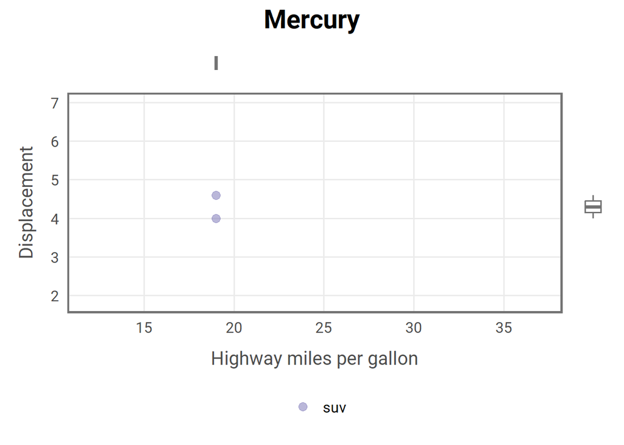

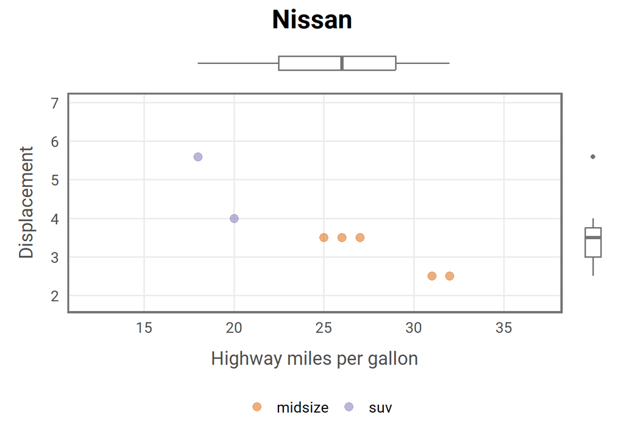

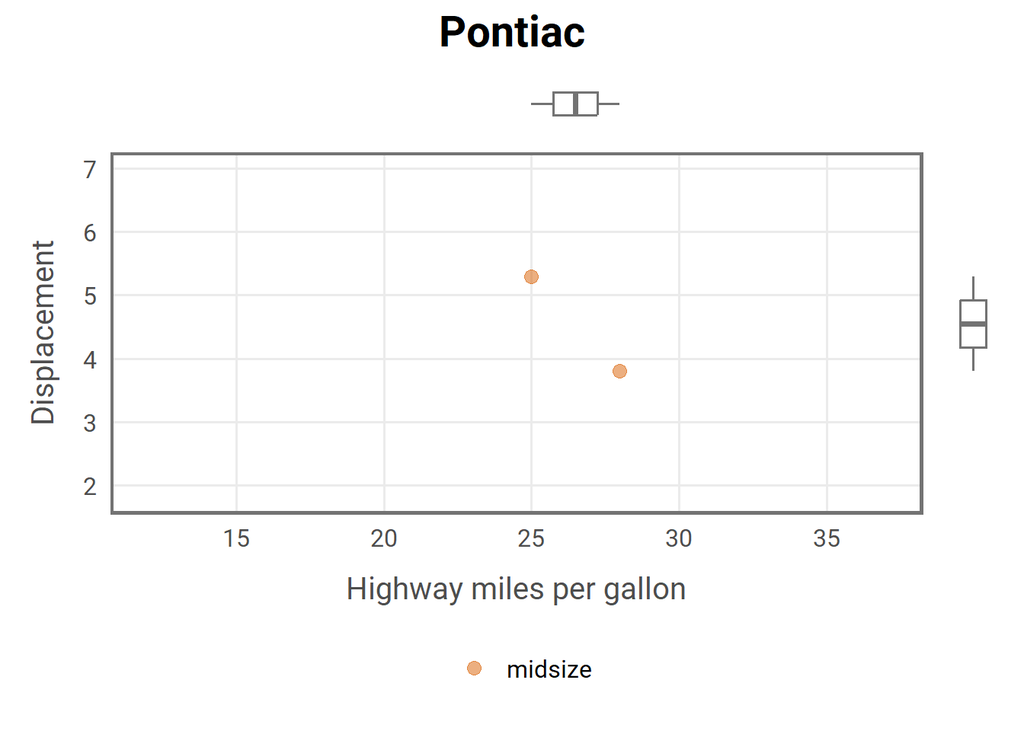

[3 more figures not shown]

```r
map(groups, ~plot_manufacturer_marginal(.x))
## [[1]]
```

## Save Plots

Earlier we stated that we can save the plots using the `walk()` function. The function is used for its effect but does not return anything

```r
walk(groups, ~plot_manufacturer_marginal(.x, save = TRUE))
```

# General Case - Variables As Inputs

To get along with this refer to data-masking referred in the introduction. The article explains in details how to make use data and environment variables within the tidy selection context and ggpplot2

The main difference is how the variables are passed in the functions

Here we will demonstrate the two vases but only shallowy

### Name Injection

Here we will pass the name of the variables as strings

```
Using !!sym() create a symbol from the character name of the variable passed in the function and unquotes it

pull(data[var1]) is equivalent to data$var1, The difference is here var1 is passed as a string `pull(data['var1'])`, but for `data$var1` var1 will be unquoted
```

**Unfold to see code**

```r
plot_scatter_lm <- function(data, var1, var2, pointsize = 2, transparency = .5, color = "") {

  ## check if inputs are valid
  if (!exists(substitute(data))) stop("data needs to be a data frame.")
  if (!is.data.frame(data)) stop("data needs to be a data frame.")
  if (!is.numeric(pull(data[var1]))) stop("Column var1 needs to be of type numeric, passed as string.")
  if (!is.numeric(pull(data[var2]))) stop("Column var2 needs to be of type numeric, passed as string.")
  if (!is.numeric(pointsize)) stop("pointsize needs to be of type numeric.")
  if (!is.numeric(transparency)) stop("transparency needs to be of type numeric.")
  if (color != "") { if (!color %in% names(data)) stop("Column color needs to be a column of data, passed as string.") }

  g <-
    ggplot(data, aes(x = !!sym(var1), y = !!sym(var2))) +
    geom_point(aes(color = !!sym(color)), size = pointsize, alpha = transparency) +
    geom_smooth(aes(color = !!sym(color), color = after_scale(prismatic::clr_darken(color, .3))),
                method = "lm", se = FALSE) +
    theme_minimal(base_family = "Roboto Condensed", base_size = 15) +
    theme(panel.grid.minor = element_blank(),
          legend.position = "top")

  ## control for continuous and categorical variable
  if (color != "") {
    if (is.numeric(pull(data[color]))) {
      g <- g + scale_color_viridis_c(direction = -1, end = .85) +
        guides(color = guide_colorbar(
          barwidth = unit(12, "lines"), barheight = unit(.6, "lines"), title.position = "top"
        ))
    } else {
      g <- g + scale_color_brewer(palette = "Set2")
    }
  }

  return(g)
}
```

### Embracing the variable

In the above case the variable are passed explicitly as strings. When embracing the variable `{{ var }}`, you pass the variable name **as-is**, you don’t pass it as a string Use embrace ({{}}) instead of creating symbols

**Unfold to see code**

```r
plot_scatter_lm_embraced <- function(data, var1, var2, color = NULL) {

  ## here are converting the variable to a string so that we can use in subsequent operations, but we will pass what was
  #| was supplied in the function with the {{ }}

  v1 <- deparse(substitute(var1))
  v2 <- deparse(substitute(var2))
  v3 <- deparse(substitute(color))

  ## check if inputs are valid
  if (!exists(substitute(data))) stop("data needs to be a data frame.")
  if (!is.data.frame(data)) stop("data needs to be a data frame.")
  if (!v1 %in% names(data)) stop("Column var1 needs to be a column of data.")
  if (!v2 %in% names(data)) stop("Column var2 needs to be a column of data.")
  if (!is.numeric(pull(data[v1]))) stop("Column var1 needs to be of type numeric.")
  if (!is.numeric(pull(data[v2]))) stop("Column var2 needs to be of type numeric.")
  if (!v3 %in% c(names(data), "NULL")) stop("Column color needs to be a column of data.")

  g <-
    ggplot(data, aes(x = {{ var1 }}, y = {{ var2 }})) +
    geom_point(aes(color = {{ color }}), alpha = .5) +
    geom_smooth(aes(color = {{ color }}), method = "lm", se = FALSE) +
    theme_minimal(base_family = "Roboto Condensed", base_size = 15) +
    theme(panel.grid.minor = element_blank(),
          legend.position = "top")

  if (v3 != "NULL") {
    if (is.numeric(pull(data[v3])))  {
      g <- g + scale_color_viridis_c(direction = -1, end = .85) +
        guides(color = guide_colorbar(
          barwidth = unit(12, "lines"), barheight = unit(.6, "lines"), title.position = "top"
        ))
    } else {
      g <- g + scale_color_brewer(palette = "Set2")
    }
  }

  return(g)
}
```

## Embrace Use Case 1

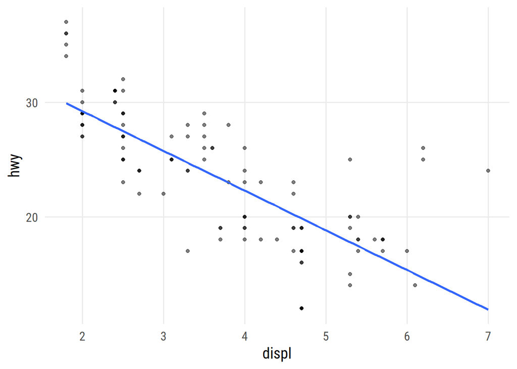

```r
plot_scatter_lm_embraced(data = mpg, var1 = displ, var2 = hwy)
## `geom_smooth()` using formula = 'y ~ x'
```